# Gear Imitation

Ernesto Carrella

August 5, 2015

So far fishers have used imitation-exploration search to decide where to go each trip. It is not hard to generalize the approach to other fisher variables.  
Here I use the same framework to make agents select their gear.

Imagine the only difference between gears is how much one unit of effort costs in term of gas. Initially each agent is assigned a random fuel consumption level per unit of effort $\sim U[0,20]$. Every 2 months the agents check their cash-flow against a random friend (in a 2-degree social network) and if the friend is doing better the copy their gear.

I run the simulation 100 times where gas is free and 100 times where gas is expensive.  
I plot the average fuel consumption level in the simulation over time. As you can see when gas is free there is no real reason to improve one’s energy efficiency so the average technology proceeds by random walk.  
However, when gas is expensive the agents very quickly imitate their friends with better technology and average fuel consumption drops dramatically.

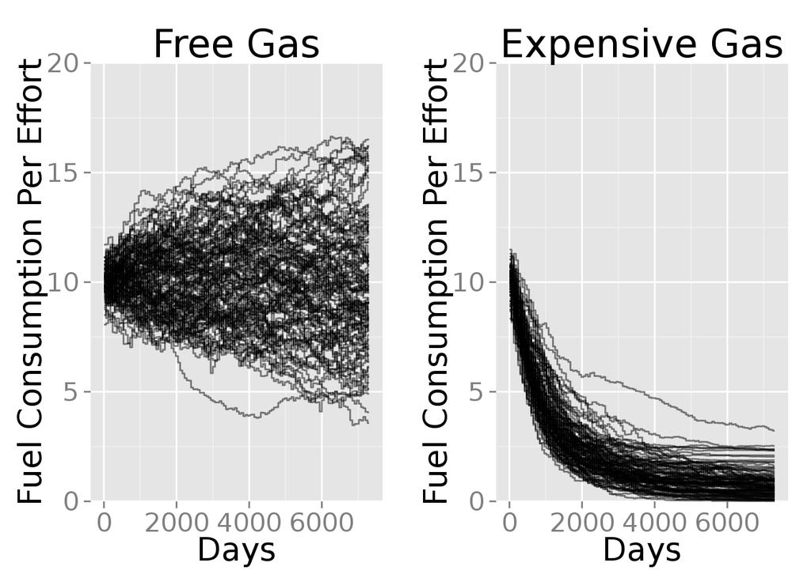

The results are very strong which is good. But a major cause of the strenght of these results is that the previous simulations were run over a “fixed biology”, that is fishers had no impact on the overall stock of fish left in the sea.  
This means that the best fishing spots are never exhausted and once discovered the fisher goes back there repeatedly.  
This in turn minimized the noise in the profits the agent make when they need to keep exploring new spots as the old ones get consumed.

In the next plot I drop the “fixed biology” assumption.  
As you can see fishers continue to adopt better fuel efficient gear but the speed of adoption is slower.  
This is because the benefits of fuel efficiency are masked by the noise of continuously exploring new fishing spots.

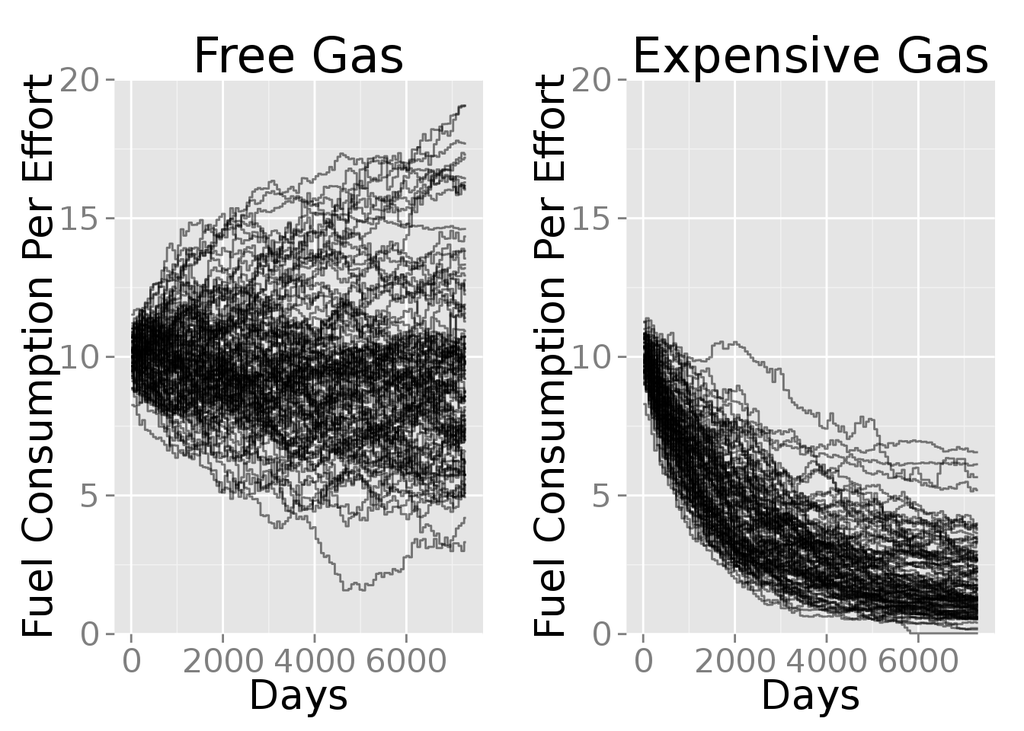

In a way the agents are now “hierarchical maximizers” in their behavior. Every trip (2-3 times a week) they run a simple maximization routine to choose where to go next. Every 2 months they run the same kind of routine to choose their gears. This is a simple trick to deal with a few dimensions but I think as the number of variables increases we will have to make agents more intelligent.

Finally, let me show one final comparison. I run 100 simulations for 3 different price levels, all without any fixed biology assumption. What I want to show is that if gas prices are very high the noise problem disappears (since exploration noise becomes small compared to the costs of fuel inefficiency):

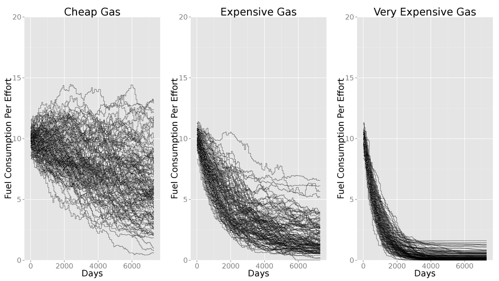